SYSTEMATIC REVIEW

published: 30 October 2018

doi: 10.3389/fphys.2018.01520

Frontiers in Physiology | www.frontiersin.org

1

October 2018 | Volume 9 | Article 1520

Edited by:

Anis Larbi,

Singapore Immunology Network

(A<sup>∗</sup>STAR), Singapore

Reviewed by:

Carsten Merkwirth,

Ferring Research Institute, Inc.,

United States

Michael Petrascheck,

The Scripps Research Institute,

United States

*Correspondence:

Andrea B. Maier

andrea.maier@unimelb.edu.au

Specialty section:

This article was submitted to

Integrative Physiology,

a section of the journal

Frontiers in Physiology

Received: 30 July 2018

Accepted: 09 October 2018

Published: 30 October 2018

Citation:

Heard DS, Tuttle CSL,

Lautenschlager NT and Maier AB

(2018) Repurposing

Proteostasis-Modifying Drugs to

Prevent or Treat Age-Related

Dementia: A Systematic Review.

Front. Physiol. 9:1520.

doi: 10.3389/fphys.2018.01520

Repurposing Proteostasis-Modifying

Drugs to Prevent or Treat

Age-Related Dementia: A Systematic

Review

Daniel S. Heard <sup>1</sup>, Camilla S. L. Tuttle <sup>2</sup>, Nicola T. Lautenschlager <sup>1,3</sup>and Andrea B. Maier <sup>2,4</sup>*

1 North West Mental Health, Melbourne Health, Melbourne, VIC, Australia, 2 @AgeMelbourne, Department of Medicine and

Aged Care, University of Melbourne, Melbourne, VIC, Australia, <sup>3</sup>Academic Unit for Psychiatry of Old Age, Department of

Psychiatry, University of Melbourne, Melbourne, VIC, Australia, <sup>4</sup>@AgeAmsterdam, Department of Human Movement

Sciences, Vrije Universiteit Amsterdam, Amsterdam Movement Sciences, Amsterdam, Netherlands

Background: Dementia has a signiﬁcant impact on quality of life of older individuals.

Impaired proteostasis has been implicated as a potential cause of dementia, that can

be therapeutically targeted to improve patient outcomes. This review aimed to collate all

current evidence of the potential for targeting proteostasis with repurposed drugs as an

intervention for age-related dementia and cognitive decline.

Methods:

PubMed, Web of Science and Embase databases were searched from

inception until 4th July 2017 for studies published in English. Interventional studies

of repurposed proteostasis-modifying drugs in Alzheimer’s disease (AD), Parkinson’s

disease (PD), Lewy Body disease, vascular dementia, and cognitive aging, in either animal

models or humans with change in cognition as the outcome were included. The SYRCLE

and Cochrane tools were used to assess risk of bias for included studies.

Results: Overall 47 trials, 38 animal and 9 human, were isolated for inclusion in this

review. Drugs tested in animals and humans included lithium, rapamycin, rifampicin,

and tyrosine kinase inhibitors. Drugs tested only in animals included Macrophage

and Granulocyte-Macrophage Colony Stimulating Factors, methylene blue, dantrolene,

geranylgeranylacetone, minocycline and phenylbutyric acid. Lithium (n = 10 animal,

n = 6 human) and rapamycin (n = 12 animal, n = 1 human) were the most studied

proteostasis modifying drugs inﬂuencing cognition. Nine of ten animal studies of lithium

showed a statistically signiﬁcant beneﬁt in Alzheimer’s models. Rapamycin demonstrated

a signiﬁcant beneﬁt in models of vascular dementia, aging, and Alzheimer’s, but may

not be effective in treating established Alzheimer’s pathology. Lithium and nilotinib had

positive outcomes in human studies including Alzheimer’s and Parkinson’s patients

respectively, while a human study of rifampicin in Alzheimer’s failed to demonstrate

beneﬁt. Microdose lithium showed a strongly signiﬁcant beneﬁt in both animals and

humans. While the risk of bias was relatively low in human studies, the risk of bias in

animal studies was largely unclear.

Heard et al.

Modifying Proteostasis to Treat Dementia

Conclusion:

Overall, the collective ﬁndings support the hypothesis that targeting

proteostasis for treatment of dementia may be beneﬁcial, and therefore future studies

in humans with repurposed proteostasis modifying drugs are warranted. Larger human

clinical trials focusing on safety, efﬁcacy, tolerability, and reproducibility are required to

translate these therapeutics into clinical practice.

Keywords: aging, alzheimer’s disease, dementia, lithium, proteostasis, rapamycin

INTRODUCTION

Dementias including Alzheimer’s disease, vascular dementia,

Parkinson’s disease and Lewy body disease, have a signiﬁcant

impact on global health due to the increasing number of older

individuals suﬀering from this disease (Prince et al., 2015).

Developing eﬀective methods for preventing, delaying or treating

dementia are pressing priorities. The highest risk factor for

dementia is chronological age, with an annual incidence of

Alzheimer’s disease doubling every 5 years past the age of 65

years (Bermejo-Pareja et al., 2008). Dementia subtypes share

several pathological processes including abnormal accumulation

of misfolded proteins such as; amyloid beta (Aβ) and tau in

Alzheimer’s disease, and alpha-synuclein in Parkinson’s disease

and Lewy Body disease (Ganguly et al., 2017). Loss of proteostasis

is an important feature during the aging process (López-Otín

et al., 2013), suggesting the age-related decline in the ability

to refold or degrade damaged proteins may contribute to the

exponential rise in dementia incidence observed with increasing

age (Yerbury et al., 2016).

Several drugs already approved for their use in humans

are known to enhance proteostasis including; lithium, mTOR

inhibitors

(sirolimus/rapamycin,

everolimus),

and

tyrosine

kinase inhibitors (nilotinib). The concept of modifying aging

with a repurposed drug to prevent multiple diseases of aging will

soon be tested in the Targeting Aging with Metformin (TAME)

trial. TAME will examine Metformin’s ability to prevent diseases

of aging in non-diabetic elderly, including cognitive impairment

(Barzilai et al., 2016), via targeting the deregulated nutrient

sensing associated with aging. Applying a similar strategy to

target the loss of proteostasis could be eﬀective in preventing

and/or treating age-related dementia.

This systematic review will examine the evidence for targeting

proteostasis with repurposed drugs as an intervention for age-

related dementia and cognitive decline.

METHODS

Protocol Registration and Search Strategy

The protocol of this systematic review was registered at

PROSPERO International prospective register of systematic

reviews (Reg #: CRD42018091645). PubMed, Web of Science

and

Embase

databases

were

used

for

this

search

from

inception until 4th July 2017. The complete search strategy is

presented in **Supplementary Data 1**. Key search terms included;

“vascular dementia,” “Alzheimer<sup>∗</sup>disease” “Lewy Body Disease,”

“Parkinson<sup>∗</sup>disease,” “cognitive aging,” “autophag<sup>∗</sup>,” “lysosom<sup>∗</sup>,”

“proteasome endopeptidase complex,” “molecular chaperone<sup>∗</sup>,”

“unfolded protein response,” “insulin<sup>∗</sup>,” “mTOR,” “GSK-3,”

“akt,” “PI3K,” “AMPK,” “sirtuin<sup>∗</sup>,” “sirolimus,” “everolimus,”

“temsirolimus,” “rapamycin,” “metformin,” “DPP-4,” “GLP-1,”

“nicotinamide,” “NAD,” “spermidine,” “imatinib,” “nilotinib,”

“dasatinib,” “bosutinib,” “ponatinib,” “bafetinib,” “lithium,” “heat-

shock protein,” “calori<sup>∗</sup>restriction,” “carbohydrate restricted

diet,” “protein restricted diet”. In addition to the database search

a “snowballing” method was used to identify relevant articles

out of the reference section and PubMed citations of each

included article. After duplicates were removed studies were

then screened for inclusion using Covidence systematic review

software (Veritas Health Innovation, Melbourne, Australia).

Eligibility Criteria

Type of Studies

The search was designed to retrieve all published research studies

that investigated the eﬀect of modifying protein homeostasis or

deregulated nutrient sensing (DNS) on cognitive function in age-

related neurodegenerative disease and normal aging populations.

To be included in this review the study had to report on one

or more neuropsychological tests measuring change in cognitive

function. To meet the criteria of modifying protein homeostasis

or deregulated nutrient sensing, the intervention had to be

previously demonstrated to modulate these pathways, or data

had to be provided proving the intervention’s eﬀect on these

pathways. Animal in vivo models and human trials were included

in this review. The following Dementia populations/models were

speciﬁcally targeted; Alzheimer’s disease, Vascular Dementia,

Parkinson’s disease and Lewy Body Disease. In addition, normal

aging populations, deﬁned as a population not suﬀering from

dementia and over the age of 18 years for human studies, as well

as populations likely to have a higher pace of aging such as animal

models with diabetes or obesity were included. Randomized

controlled trials (RCTs) and non-randomized studies comparing

outcomes to either retrospective or prospective controls met the

inclusion criteria. Studies were excluded if they met the following

criteria; observational studies, exercise as the sole intervention, in

vitro data only, conference abstracts, reviews, editorials, letters to

the editor, case reports with ≤5 population size, or published in a

language other than English.

Outcome

In animals (using mice as an example), cognitive tests would

include spatial memory tests (Morris water maze [MWM],

radial arm water maze [RAWM], Barnes maze), associative

learning tasks (passive avoidance, fear conditioning), alternation

Frontiers in Physiology | www.frontiersin.org

2

October 2018 | Volume 9 | Article 1520

Heard et al.

Modifying Proteostasis to Treat Dementia

tasks (Y-Maze/T-Maze), recognition memory tasks (Novel

Object Recognition), attentional tasks (3 and 5 choice serial

reaction time), set-shifting tasks, and reversal learning tasks.

In human studies examples of neuropsychological measures

would be cognitive testing batteries commonly used in clinical

or research settings to examine cognitive function, such as the

Mini-Mental State Examination (MMSE), Rowland Universal

Dementia Assessment Scale (RUDAS), Neuropsychiatry Unit

Cognitive Assessment Tool (NUCOG), Montreal Cognitive

Assessment (MOCA), Clinical Dementia Rating Scale Sum of

Boxes (CDR-SoB), Addenbrooke’s Cognitive Examination (ACE)

or Alzheimer’s Disease Assessment Scale-cognitive subscale

(ADAS-Cog).

Study Selection

Two review authors (DH and CT) independently screened the

titles and abstracts and subsequently the full text articles of

potentially relevant studies against the inclusion and exclusion

criteria. A third reviewer (ABM) resolved any disagreements

between the authors.

Included studies were separated into the following four

groups for data extraction (1) proteostasis–repurposed drug, (2)

proteostasis–novel intervention (deﬁned as a novel molecule,

botanical extract, or dietary manipulation), (3) DNS–repurposed

drug and (4) DNS–novel intervention. Where an intervention

is thought to modify both pathways (for example the mTOR

inhibitor, rapamycin) it was included in the loss of proteostasis

group. The current paper presents the results of the 1st group:

proteostasis—repurposed drugs.

Data Extraction and Quality Assessment

The following variables were extracted independently by two

reviewers (DH and CT): author, year of publication, study design,

species, animal model/population (dementia subtype or normal

aging), sample size, age, sex, baseline cognition/stage of disease,

duration of study, cognitive outcome, drug, comparator, setting,

hallmark(s) of aging targeted by the intervention, and journal

citation. For binary outcomes the number of events and total

number in group, percentage of events or ratios with conﬁdence

intervals; for continuous outcomes, mean or median, standard

deviation, standard error, conﬁdence intervals or interquartile

range, and number of participants; other reported results such as

mean diﬀerence and p-values of measures of cognitive function.

Risk of bias was assessed by two reviewers (DH, CT) using

the Cochrane Risk of Bias tool (Higgins et al., 2011) for human

studies and SYRCLE’s risk of bias tool for animal studies. The

SYRCLE RoB tool is an adaptation of the Cochrane tool for use in

systematic reviews of laboratory animal studies (Hooijmans et al.,

2014).

Registered Human Trials

To establish the progress of repurposed drugs into human

studies which have not yet been completed, clinicaltrials.gov was

searched for registered studies of the drugs identiﬁed in our

search in Alzheimer’s disease, Parkinson’s disease, Lewy Body

Disease and Vascular Dementia.

RESULTS

Study Selection and Characteristics

The literature search and selection process for this review

is illustrated in **Figure 1**. After exclusion of duplicates the

remaining 1,687 studies were screened for Title and Abstracts

of which 413 underwent full text screening. An additional

22 studies were identiﬁed via snowballing. Overall, 47 articles

speciﬁcally investigating a proteostasis intervention on Dementia

and cognitive aging were included in this review. The repurposed

drugs used in these intervention studies are outlined in

**Tables 1**, **2** and **Supplementary Table 1**. The following drugs

were found testing the modiﬁcation of cognition in animal and

human studies; lithium (n = 10 animal, n = 6 human), rapamycin

(n = 12 animal, n = 1 human), rifampicin (n = 1 animal,

n = 1 human), tyrosine kinase inhibitors (bosutinib n = 1

animal, nilotinib n = 1 human), Macrophage Colony Stimulating

Factor (M-CSF; n = 1 animal), Granulocyte Macrophage Colony

Stimulating Factor (GM-CSF; n = 1 animal), methylene blue

(n = 4, animal), geranylgeranylacetone (GGA; n = 2 animal),

dantrolene (n = 3 animal), minocycline (n = 2 animal) and

phenylbutyric acid (n = 1 animal). Doxycycline was tested in a

single human trial only. Of these drugs only lithium, rapamycin,

rifampicin, and the tyrosine kinase inhibitors have been tested in

both animal and human studies (**Figure 2**).

Lithium and Cognitive Aging

Lithium was the most investigated proteostasis modulator for

cognitive aging. Overall 16 studies (6 humans, 6 mice, 2 rats,

1 drosophila, and 1 zebraﬁsh) investigating the inﬂuence of

lithium on cognitive aging were found. The majority of these

studies utilized an Alzheimer’s animal model or were conducted

in an Alzheimer’s population (**Tables 1**, **2**). The ﬁndings of

these studies were largely positive with all animal studies, bar

one (Caccamo et al., 2007), reporting the use of lithium as

having a statistically signiﬁcant beneﬁcial impact on at least one

cognitive outcome irrespective of treatment duration (**Table 3**).

The ﬁndings of the animal studies are consistent with the lithium

human studies (**Table 4**), with three randomized controlled

studies showing a statistically signiﬁcant beneﬁt of the use

on lithium on either the ADAS-Cog or MMSE (Leyhe et al.,

2009; Forlenza et al., 2011; Nunes et al., 2013). The other

three studies, two of which were open-label (Pomara et al.,

1983; Macdonald et al., 2008) and one RCT (Hampel et al.,

2009), did not show cognitive beneﬁts after treatment with

lithium.

Rapamycin and Cognitive Aging

Rapamycin has been identiﬁed as the second most frequently

investigated

(n

=

13

studies)

proteostasis

modulator.

Twelve

animal

studies

(10

mice,

2

rats),

predominately

using

an

Alzheimer’s

disease

model,

investigated

the

inﬂuence

of

rapamycin

on

cognitive

aging

(**Table 1**).

Overall,

nine

out

of

twelve

animal

studies

reported

a

statistically

signiﬁcant

beneﬁt

on

at

least

one

cognitive

outcome, irrespective of treatment duration (**Table 3**). One

human study investigating safety, eﬃcacy and tolerability of

Frontiers in Physiology | www.frontiersin.org

3

October 2018 | Volume 9 | Article 1520

Heard et al.

Modifying Proteostasis to Treat Dementia

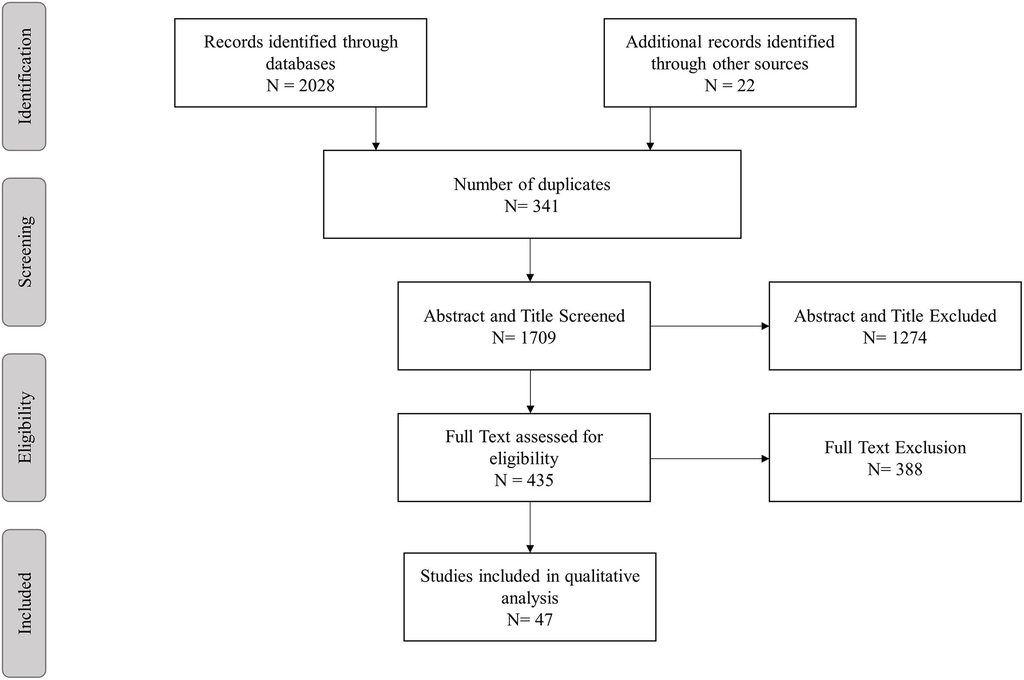

FIGURE 1 | Study selection process.

rapamycin in humans (Kraig et al., 2018), did not report any

signiﬁcant beneﬁt to overall cognition in an older population

(**Table 4**).

Rifampicin, Tetracycline Antibiotics,

Tyrosine Kinase Inhibitors and Cognitive

Aging

Rifampicin,

tetracycline

antibiotics

and

tyrosine

kinase

inhibitors have been tested in both animal and human

models

(**Tables 1**,

**2**).

The

two

rifampicin

studies

(1

mouse, 1 human; **Tables 3**, **4**) investigating its therapeutic

eﬀects for Alzheimer disease had opposite ﬁndings, with

positive cognitive outcomes in mice (Umeda et al., 2016),

but no beneﬁt found in the human study (Molloy et al.,

2013).

Studies of tetracycline antibiotics showed similar results

to rifampicin, with minocycline showing cognitive beneﬁts

in two studies using rat and chicken models of Alzheimer

disease (**Supplementary Table 1**, **Supplementary Table 2**), while

another tetracycline, doxycycline, showed no beneﬁt in human

AD patients, either alone or in combination with rifampicin

(Molloy et al., 2013).

The tyrosine kinase inhibitor, bosutinib, was reported in

mouse models of Alzheimer’s disease as statistically beneﬁcial

to cognitive function, and another tyrosine kinase inhibitor,

nilotinib, was found to improve scores on the MMSE and

SCOPA-Cog in an open-label study in patients with Parkinson’s

disease, however the statistical signiﬁcance was not reported

(**Tables 3**, **4**).

Other Proteostasis-Modifying Drugs

There were six proteostasis modulators that have been tested

to improve cognitive outcomes in animal models but are

yet

to

be

studied

in

human

populations—M-CSF,

GM-

CSF, methylene blue, GGA, dantrolene, and phenylbutyric

acid

(**Supplementary Table 1**).

Both

of

the

M/GM-CSF

studies indicated beneﬁcial outcomes with the use of these

therapeutics in mouse models of Alzheimer’s disease, as

was the case with methylene blue, GGA and phenylbutyric

acid

(**Supplementary Table 2**).

Studies

of

dantrolene

to

improve cognitive outcomes showed a statistically signiﬁcant

improvement in one mouse model of Alzheimer’s (Peng et al.,

2012) but no beneﬁt to cognition in another (Wu et al., 2015),

with one study in aged rats indicating a trend toward beneﬁt on

Morris water maze performance.

Frontiers in Physiology | www.frontiersin.org

4

October 2018 | Volume 9 | Article 1520

Heard et al.

Modifying Proteostasis to Treat Dementia

TABLE 1 | Characteristics of animal studies testing the effect of lithium (a), rapamycin (b), rifampicin (c), bosutinib (d) on cognition.

Author, Year

Species

Model

Sample size (n)

Age

Sex

(%F)

Baseline

cognition

Duration

Dose

Rx

Ctrl

a

Caccamo et al., 2007

Mouse

AD (3xTg)

Wt: 10

Tg: 10

Wt: 10

Tg: 10

15m

NR

Est

4w

300µl of

0.6mol/L/d IP

a

Rockenstein et al.,

2007

Mouse

AD (Tg hAPP)

WT: 6

Tg: 6

WT: 6

Tg: 6

3m

NR

Est

3m

20mg/kg/d IP

a

Fiorentini et al., 2010

Mouse

AD (TgCRND8)

Ear: 8

Est: 8

Ear: 8

Est: 8

2m

6m

Mix

Ear

Est

5w

0.223mEq/L

IP

a

Toledo and Inestrosa,

2010

Mouse

AD (Tg APP- PS1)

3-≥6

3-≥6

9m

NR

Est

12w

0.2–1.5

meq/L

a

Sy et al., 2011

Mouse

AD (3xTg)

Na = 6

LPS = 6

Na = 6

LPS = 6

11–13m

67

Est

6w

6–10mg/d

food

a

Nunes et al., 2015

Mouse

AD (Cg-

Tg(PDGFB-

APPSwInd)

20Lms/2J)

Pre: 8

Est: 7

WT: NR.

WT: 12

TG: 7

2m

10m

0

Pre

Est

16m

8m

0.25mg/kg/d

(H2O)

a

Nocjar et al., 2007

Rat

Aging

(Sprague-Dawley)

16

14

2m

0

Pre

80d

0.72mEq/l

food

a

Wilson et al., 2017

Rat

AD (Tg McGill-

R-Thy1-APP)

WT: ≥5

Tg:≥5

WT: ≥5

Tg:≥5

3m

Mix

Ear

2m

Li 40µg/kg/d

PR

a

Nery et al., 2014

Zebraﬁsh

AD (ICV Aβ)

No inj: 10

Veh: 10

AB: 10

No inj: 10

Veh: 10

AB: 10

5d

Mix

Pre

5d

100µm (H2O)

a

McBride et al., 2010

Drosophila

AD (Tg psn[B3]/+,

psn[I2]/+) PD (Tg

30Y-GAL4:UAS-

Syn)

Pre: 72

Pre: 70

30d

0

Pre

25d

5mM Li food

Est: 74

Est: 75

45d

Est

15d

PD: 39

PD: NR

b

Spilman et al., 2010

Mouse

AD (Tg hAPP)

Aging (C57BL/6J)

12

10

12

10

7m

0

Ear

YA

3m

14mg/kg food

b

Majumder et al., 2011

Mouse

AD (3xTg)

Aging (C57BL6/

129svj)

40

40

20

20

18m

NR

Pre

Est

16m

3m

14mg/kg food

b

Halloran et al., 2012

Mouse

Aging (C57BL/6J)

9–14

9–14

12m

25m

Mix

MA

OA

40w

14mg/kg food

b

Majumder et al., 2012

Mouse

Aging (C57BL/6/

129svj)

20

20

20

18m

NR

YA

MA

16m

3m

14mg/kg food

b

Lin et al., 2013

Mouse

AD (Tg hAPP)

Tg: 10

Tg: 10

7m

0

Est

16w

14mg/kg food

WT: 18

WT: 17

YA

b

Neff et al., 2013

Mouse

Aging (C57BL/6Jrj)

YA: 20

YA: 20

4m

0

YA

12m

14mg/kg food

MA: 21

MA: 21

13m

MA

OA: 27

OA: 27

20–22m

OA

b

Wang et al., 2014

Mouse

Aging (C57BL/6J,

stz diabetic)

9

9

3m

0

Est

45d

2.24mg/kg/d

PO

b

Lin et al., 2015

Mouse

AD (APOE4 Tg)

15

15

7m

100

Pre

6m

14mg/kg food

b

Jahrling et al., 2017

Mouse

VD (LDL-R–/–

HFD)

10

10

12m

0

Est

16w

14mg/kg food

b

Zhang et al., 2017

Mouse

AD (3xTg)

10

10

7m

50

Ear

2m

1mg/kg/d PO

b

Wang et al., 2016

Rat -

Sprague

Dawley

AD (ICV Aβ)

18

20

6m

0

Pre

2w

500 microg

ICV/2w

b

Zhu et al., 2014

Rat

AD (scop Wistar)

10

10

NR

0

Pre

14d

3.5mg/kg/d

IP

(Continued)

Frontiers in Physiology | www.frontiersin.org

5

October 2018 | Volume 9 | Article 1520

Heard et al.

Modifying Proteostasis to Treat Dementia

TABLE 1 | Continued

Author, Year

Species

Model

Sample size (n)

Age

Sex

(%F)

Baseline

cognition

Duration

Dose

Rx

Ctrl

c

Umeda et al., 2016

Mouse

AD (Tg

APPOSK),

(tau609)

Aging (WT)

APPOSK

APPOSK

APP

0

Est

1m

0.5mg/d

(APP12m,

APP18m,

tau8m)

1mg/d PO

(APP18m,

tau15m)

12m

12m: 9

11m

0.5mg: 9

18m: 10

17m

18m

WT

0.5mg:

10

8m: 10

Tau

1mg: 10

12m: 10

7m

Tau609

15m: 11

14m

8m

18m: 16

0.5mg: 8

Tau609

15m

8m: 9

1mg: 7

15m: 7

d

Lonskaya et al., 2013

Mouse

AD (ICV lentiviral

Aβ42, C57BL6)

AD (Tg APP

model)

Aβ42: 12

Aβ42: 12

11m

NR

Est

3w

5mg/kg/d IP

Tg: 12

Tg: 12

3xTg, triple transgenic; Aβ, amyloid beta; AD, Alzheimer’s dementia; Ctrl, control; d, days; Ear, early disease; Est, established; F, female; hAPP, human amyloid precursor J20; HFD, High

fat diet; ICV, intracerebroventricular; Inj, injection; IP, intra-peritoneal; LDL-R–/–, low density lipoprotein receptor knockout; Li, lithium; LPS, lipopolysaccharide; m, months; MA, middle

age; NR, not reported; OA, Old Age; PD, Parkinson’s disease dementia; PO, per oral; PR, per rectum; Pre, presymptomatic; Rapa, rapamycin; Scop, scopolamine; stz, streptozocin

induced; Tg, transgenic; VD, vascular dementia; w, weeks; WT, wild type; YA, young adult.

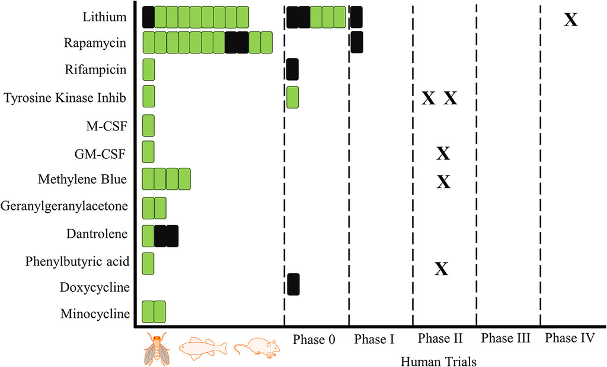

FIGURE 2 | Proteostasis Drugs and Cognitive Outcomes: From Animals to Humans. A schematic overview of trials investigating the inﬂuence of proteostasis drugs on

cognitive outcomes. One bar is equal to one trial, green indicates a positive result for at least one cognitive outcome and black is indicative of no positive outcomes. X

represents a registered trial. Trials are arranged in chronological order.

Risk of Bias

**Table 5** shows the SYRCLE risk of bias ratings for animal studies.

The majority of animal studies had an unclear risk of bias, as

speciﬁc details of randomization and blinding were often not

provided. Most studies provided information on the baseline

characteristics of animals, and some studies did specify that the

investigator performing behavioral assessments of the animals

was blinded to the treatment status of the animal, indicating low

risk of bias where this was the case. Overall the risk of bias was

similar across studies regardless of the drug being tested.

**Table 6** shows the Cochrane risk of bias rating for human

studies. There was signiﬁcant heterogeneity among lithium

Frontiers in Physiology | www.frontiersin.org

6

October 2018 | Volume 9 | Article 1520

Heard et al.

Modifying Proteostasis to Treat Dementia

TABLE 2 | Characteristics of human studies testing the effect of lithium (a), rapamycin (b), rifampicin & doxycycline (c) and nilotinib (d) on cognition.

Author, year

Design

Condition

Sample size (n)

Age (yrs)

Female

(%)

Baseline

cognition

Duration

Dose

Rx

Ctrl

Rx

Ctrl

a

Pomara et al., 1983

OL

(pre-post)

AD

7

NA

“Geriatric”

NR

NR

6w

0.53 mmol/L

(mean at 6w)

a

Macdonald et al.,

2008

OL (match

ctrl)

AD

22

44

80.9 ± 7.9

81.2

59

MMSE 12–24

12m

0.3–0.8

mmol/L

a

Hampel et al., 2009

RCT

AD

33

38

68.2 ± 7.2

68.9 ± 8.3

52

MMSE 21–26

10w

0.5–0.8

mmol/l

a

Leyhe et al., 2009

RCT

AD

13

14

71.0 ± 9.0

69.4 ± 8.5

59

MMSE 21–26

10w

0.5–0.8

mmol/L

a

Forlenza et al., 2011

RCT

AD-MCI

23

22

70.9 ± 5.3

74.2 ± 6.5

NR

MCI

12m

0.25–0.5

mmol/L

a

Nunes et al., 2013

RCT

AD

58

55

77.0 ± 0.1

78.0 ± 0.76

66

MMSE 12–24

15m

300 µg/d

b

Kraig et al., 2018

RCT

Aging

11

14

80.4 ± 8.6

80.6 ± 7.9

28

OA

8w

1mg/d PO

c

Molloy et al., 2013

RCT

AD

Rif: 101

Dox: 102

Rif + dox:

101

102

Rif:78.6

(73.5–82.3)

Dox: 78.7

(74.1–83.6)

Rif+dox:79.2

(74.4–83.5)

78.6

(72.4–83)

50

MMSE 20–25

12m

Rif: 300mg/d

Dox: 100mg

BD Rif + dox:

300mg/d +

100mg BD

d

Pagan et al., 2016

OL (pre-post)

PD

12

NA

71.8 (49–89)

NA

25

MoCA 9–28

6m

Nilo 150mg or

300mg/d

OL, open label; RCT, randomized controlled trial; AD, Alzheimer’s Disease, PD, Parkinson’s disease; LBD, Lewy Body Disease; MMSE, Mini mental state exam; MoCA, Montreal Cognitive

Assessment; NR, not reported; SD, standard deviation; MCI, Mild Cognitive Impairment; Li, lithium; Ctrl, control; NA, Not applicable; D, days; W, weeks; M, months; Rx, treatment; Rif,

rifampicin; Dox, doxycycline; PL, placebo; Nilo, nilotinib; Age, refers to age at baseline of study.

studies, with (Pomara et al., 1983; Macdonald et al., 2008)

scoring high risk of bias across most or all domains due to an

open label design and not reporting all quantitative outcome

data. (Hampel et al., 2009) had an intermediate risk of bias

as investigators were aware of patient treatment status. Studies

by Leyhe et al. (2009), Forlenza et al. (2011) and Nunes

et al. (2013) scored a lower risk of bias due to randomized,

double-blind designs, though details of sequence generation

and allocation concealment were not reported. Studies of

rapamycin (Kraig et al., 2018) and rifampicin (Molloy et al.,

2013) scored a low risk of bias across most domains. The

study using nilotinib (Pagan et al., 2016) was rated as having

a high risk of bias across most domains, due to an open label

design.

Registered Human Trials

**Figure 2** shows the progress of the drugs identiﬁed in our

search from animal into human studies, including planned

or ongoing studies registered on clinicaltrials.gov. Nilotinib

has two phase 2 studies registered, one in Alzheimer’s

disease and one in Parkinson’s disease. Lithium has one

disease.

DISCUSSION

In this review we have summarized all current animal and human

research studies that have investigated the eﬀect of proteostasis

modulators on cognitive function. Overall, the therapeutic

alteration of proteostasis pathways using repurposed drugs is a

promising approach to the treatment of dementia and age-related

cognitive decline with a reasonable research translation between

animal and human studies showing similar conclusions observed

across the studies.

Lithium

Lithium was the most studied proteostasis modifying drug

identiﬁed in this review, and the furthest progressed in

translation to treatment of age-related dementia. All except one

of the animal studies included in this review showed a beneﬁt to

at least one cognitive outcome despite heterogeneity in species,

model, dose, stage of disease at intervention and duration of

treatment. Three of six human studies also found beneﬁt, and

consistent with the results in mice the largest eﬀect was observed

with microdoses and long duration of treatment (Nunes et al.,

2013). The only negative RCT used a high dose for a short

duration (Hampel et al., 2009). Taken together, these studies show

lithium has a consistent beneﬁt in Alzheimer’s disease in animal

models and humans, which appears more pronounced with lower

Frontiers in Physiology | www.frontiersin.org

7

October 2018 | Volume 9 | Article 1520

Heard et al.

Modifying Proteostasis to Treat Dementia

TABLE 3 | Results of animal studies testing the effect of lithium (a), rapamycin (b), rifampicin (c) and bosutinib (d) on cognition.

Author, year

Cognitive tests

Outcomes

Signiﬁcance

a

Caccamo et al., 2007

T-maze (Alternation %)

Wt Li−66.67 (8.7), ctrl−72.15 (2.4)

±

Tg Li−55.71 (5.6), ctrl−55.21 (5.8)

±

a

Nocjar et al., 2007

Hole-board spatial discrimination

task:

Search time (s) session 6

Li−6 (1), Ctrl−20 (3)

+

Repeat visits (# lower=better)

Li−0.6 (0.1), Ctrl−1.5 (0.4)

+

Number of errors (# lower=better)

Li−1.6 (0.2), Ctrl−1.9 (0.2)

±

T-maze delayed alternation task:

Sessions to reach criterion (#)

Li−13.5 (1), Ctrl−20 (1.5)

+

Social conditioned place preference:

Percent correct (%)

1min Li−75 (2.5), Ctrl−72.5 (5)

±

3min Li−70 (3), Ctrl−58 (4)

+

5min Li−65 (2.5), Ctrl−60 (2.5)

±

Run time (min)

1min Li−3.7 (1), Ctrl−1.9 (0.2)

NR

3min Li−2.7 (0.5), Ctrl−2.8 (0.5)

±

5min Li−2.9 (0.5), Ctrl−3.2 (0.5)

±

Preference for social chamber (s):

Li−280 (100), Ctrl−175 (100)

+

a

Rockenstein et al., 2007

Morris water maze:

Meters to reach platform day 7

Tg Li−3 (0.5), ctrl−11.5 (3)

+

Wt Li−3.25 (0.5), ctrl−3 (0.5)

Platform crosses (#)

Tg Li−7 (1.5), ctrl−6 (1)

±

Wt Li−6 (2), ctrl−7 (1)

Time in target quadrant (s)

Tg Li−16 (3), ctrl−18 (2)

±

Wt Li−15 (3), ctrl−16 (3)

a

Fiorentini et al., 2010

Morris water maze:

Early stage disease (3 months)

Escape latency day 4 (s)

Li 35s (5s), ctrl 55s (2s)

+ + +

Time in target section (%)

Li 7.4% (2.25%), ctrl 1.25% (1.25%)

++

Inhibitory avoidance test (s)

Li 27 (3), ctrl 9.5 (2)

+ + +

Late stage disease (7 months)

Escape latency day 4 (s)

Li 50 (2), ctrl 59 (1)

NR

Time in target section (%)

Li 1.5 (0.5), ctrl 1.5 (0.5)

±

Inhibitory avoidance test

Li 14 (3.5), ctrl 8 (4)

±

a

Toledo and Inestrosa, 2010

Morris water maze:

Escape latency day 5 (s)

Tg Li−45 (9), ctrl−35 (7.5)

±

WT ctrl−27 (10)

Memory ﬂexibility test:

No. of trials to criterion (#)

Tg Li−7 (0.5), ctrl 12 (0.25)

+

WT ctrl−5 (0.25)

a

Sy et al., 2011

Morris water maze:

Escape latency during day 7 (s)

Li + Na−25 (2), ctrl + Na−17 (5)

NR

Li + LPS−26 (3), ctrl + LPS−20 (3)

NR

Probe trial (24 h)

Time spent in target quadrant (s)

Li + Na−17.5 (4.5), ctrl + Na−22 (4)

±

Li + LPS−19 (2), ctrl + LPS−13 (4)

±

Latency to platform (s)

Li + Na−24 (6), ctrl + Na−17.5 (5)

±

Li + LPS−26 (5), ctrl + LPS−47.5 (7.5)

+

Number of platform location crosses (#)

Li + Na−5 (1.3), ctrl + Na−5.4 (1)

±

Li + LPS−3 (0.25), ctrl + LPS−1 (0.5)

+

(Continued)

Frontiers in Physiology | www.frontiersin.org

8

October 2018 | Volume 9 | Article 1520

Heard et al.

Modifying Proteostasis to Treat Dementia

TABLE 3 | Continued

Author, year

Cognitive tests

Outcomes

Signiﬁcance

a

Nunes et al., 2015

Barnes maze:

Treated before deﬁcits

Escape latency (s; mean)

Li−40 (3), ctrl−75 (7)

+

Time in target quadrant (%)

Li−52.3 (6.8) Ctrl−22.8 (4.9)

+ + +

Aversive memory test session (s)

Li−299 (298/300), Ctrl−216 (137/298)

++

Barnes maze:

Treated after deﬁcits

Escape latency (s; mean)

Li – 25 (2), Ctrl – 75 (7)

+

Time in target quadrant (%)

Li−32 (4) Ctrl−22.8 (4.9)

++

Aversive memory test session (s):

Li−298 (139/298), Ctrl−216 (137/298)

+

a

Wilson et al., 2017

Novel object recognition (preference

ratio)

WT Li−0.39 (0.04), veh−0.43 (0.04)

Tg AD Li−0.39 (0.02) veh−0.28 (0.02)

NR

+

Morris water maze:

Escape latency training day 5 (s)

WT Li−31 (7), veh−15 (5)

NR

Tg Li−40 (10) AD veh−33 (8)

±

Time in target quadrant (%)

WT Li−44 (5), veh−48 (5)

±

Tg AD Li−45 (3), veh−50 (8)

±

Auditory fear conditioning task:

Contextual (% freezing)

WT Li−60 (15), veh−79 (11)

±

Tg AD Li−60 (10) veh−55 (10)

±

Cued recall (% freezing)

WT Li−55 (15), veh−85 (10)

NR

Tg AD Li−63 (7), veh−30 (5)

+

a

Nery et al., 2014

Avoidance behavior

% animals in non-stimulus area

Aβ inj Li 65 (2), ctrl: 55 (1)

+ + +

a

McBride et al., 2010

Treated before deﬁcits

Alzheimer’s Tg:

Learning during training (%)

psn[B3]/+ ﬂies

Li 75(5) -> 45(10), ctrl 62.5(7.5) -> 51 (9)

+ + +

psn[I2]/+ ﬂies

Li 65(7.5) -> 30(10) ctrl 63(8) -> 52(8)

+ + +

Short term memory (%)

psn[B3]/+ ﬂies

Li–Naive 90(2), trained 70(5)

++

Ctrl–Naive 76(6), trained 75(6)

±

psn[I2]/+ ﬂies

Li–Naive 88(2), trained 72(5)

+

Ctrl–Naive 83(5), trained 85 (3)

±

Treated after deﬁcits

Learning during training (%)

psn[B3]/+ ﬂies

Li 65(7.5) -> 18(7), ctrl 70(5) -> 62.5(7.5)

+ + +

psn[I2]/+ ﬂies

Li 76(5) -> 18(7), ctrl 47.5(7.5) -> 35(7.5)

+ + +

Short term memory (%)

psn[B3]/+ ﬂies

Li–Naive 90(4), trained 62.5(7.5)

++

Ctrl–Naive 70(8), trained 75(7)

±

psn[I2]/+ ﬂies

Li–Naive 84(6), trained 62.5(7.5)

++

Ctrl–Naive 57.5(7.5), trained 63(8)

±

Treated before deﬁcits

Short term memory

Parkinson’s Tg:

Li 80(4) -> 75(5), ctrl 82.5(5) -> 78(4)

±

b

Spilman et al., 2010

Morris water maze:

Escape latency day 4 (s)

Tg Rapa 32(3), ctrl 42(5)

+

WT Rapa 15(2.5), ctrl 32.5(3)

NR

Platform crosses (#)

Tg Rapa 2.5(0.5), ctrl 0.9(0.1)

+/±

WT Rapa 5(1), ctrl 3.1(0.4)

NR

(Continued)

Frontiers in Physiology | www.frontiersin.org

9

October 2018 | Volume 9 | Article 1520

Heard et al.

Modifying Proteostasis to Treat Dementia

TABLE 3 | Continued

Author, year

Cognitive tests

Outcomes

Signiﬁcance

b

Majumder et al., 2011

Morris water maze:

Escape latency day 5 (s)

Pre-AD–Rapa 26.9(2.1), ctrl 37.96(2.9)

+

Est AD – Rapa 36(2), ctrl 37.96(2.9)

±

YA–Rapa 20.7(1.05), ctrl 29.1(2.7)

+

MA–Rapa 32.5(1.5), ctrl 29.1(2.7)

±

Trial time in target quadrant (s)

Pre-AD–Rapa 22.5(2.5), ctrl 15(2.5)

+

Est AD–Rapa 17.5(1.5), ctrl 15(2.5)

±

YA–Rapa 29(2), ctrl 21.5(1.5)

+

MA–Rapa 21(1.5), ctrl 21.5(1.5)

±

MWM platform crosses (#)

Pre-AD–Rapa 3.5(0.5), ctrl 1.95(0.25)

+

Est AD–Rapa 1.75(0.2), ctrl 1.95(0.25)

±

YA–Rapa 5.25(0.3), ctrl 3.8 (0.25)

+

MA–Rapa 3.5 (0.2), ctrl 3.8 (0.25)

±

Novel object recognition

Pre-AD–Rapa 65 (7), ctrl 50 (5)

+

Est AD–Rapa 55 (2.5), ctrl 50 (5)

±

YA–Rapa 67.5(2.5), ctrl 70 (4)

±

MA–Rapa 60 (5), ctrl 70 (4)

±

b

Halloran et al., 2012

Passive avoidance test (s)

MA–Rapa 200(40), ctrl 160(40)

±

OA–Rapa 200(30), ctrl 100(20)

+

b

Majumder et al., 2012

Morris water maze:

Escape latency day 5 (s)

YA–Rapa 21(1), ctrl 30(2.5)

+

MA–Rapa 31(2), ctrl 30(2.5)

±

Time in target quadrant (s)

YA–Rapa 28.73(1.65), ctrl 21.3(1.24)

++

MA–Rapa 20.97(1.18), ctrl 21.3(1.24)

±

Latency to platform (s)

YA–Rapa 20(2), ctrl 27(3)

+

MA–Rapa 31(3), ctrl 27(3)

±

Platform crosses

YA–Rapa 5.3(0.2), ctrl 3.9(0.15)

+ + +

MA–Rapa 3.5(0.25), ctrl 3.9 (0.15)

±

b

Lin et al., 2013

Morris water maze:

Escape latency day 5 training (s)

WT–rapa 28(4), ctrl 25(3)

AD–rapa 35(9), ctrl 40(4)

±

Platform crosses (#)

WT rapa−3.1(0.5), ctrl 3.9(0.6)

AD rapa−2.1 (0.5), ctrl−0.75 (0.25)

+

b

Neff et al., 2013

Object place recognition (s)

YA rapa–novel 22(3), known 12(2)

±

YA veh–novel 24(4), known 14(2)

MA rapa–novel 15(3), known 10(2)

±

MA veh–novel 17(2), known 15(4)

Morris water maze:

Escape latency day 5 (s)

YA rapa 30(1), veh 41 (2)

+/±

MA rapa 37 (3), veh 39 (1)

+/±

Time in target quadrant (s)

YA rapa 25(2), veh 21 (2)

++

MA rapa 25 (2), veh 20 (3)

++

Target crossings (#)

YA rapa 2.3(0.2), veh 1.3(0.2)

++

MA rapa 1.5 (0.3), veh 1.5 (0.2)

±

Context fear conditioning:

Activity suppression (ratio)

YA rapa 0.2 (0.02), veh 0.21 (0.02)

++

MA rapa 0.195 (0.01), veh 0.28 (0.02)

++

OA rapa 0.195 (0.01), veh 0.25 (0.04)

++

b

Wang et al., 2014

Morris water maze:

Escape latency day 4 (s)

Rapa 25(3), ctrl 35(4)

+

Escape latency trial (s)

Rapa 16(5), ctrl 32(2.5)

++

Time in target quadrant (s)

Rapa 26(3.5), ctrl 12.5(1)

++

(Continued)

Frontiers in Physiology | www.frontiersin.org

10

October 2018 | Volume 9 | Article 1520

Heard et al.

Modifying Proteostasis to Treat Dementia

TABLE 3 | Continued

Author, year

Cognitive tests

Outcomes

Signiﬁcance

b

Zhu et al., 2014

Morris water maze:

Escape latency (s)

Scop + rapa−50 (7.5)

−

Scop + saline−38 (5)

++

Saline only−55 (7)

Scop + rapa + MAD−39 (4)

+

Time in target quadrant (%)

Scop + rapa−65 (7)

−

Scop + saline−80 (8)

+

Saline only−62 (6)

Scop + rapa + MAD−75 (7.5)

+

b

Lin et al., 2015

Morris water maze:

Escape latency (s)

Rapa 25(1), ctrl 19(2)

±

Platform crosses (#)

Rapa 1.6(0.25), ctrl 1.75(0.25)

±

b

Wang et al., 2016

Y-maze (alternation %):

4wks post infusion

Rapa 39(6), ctrl 62(10)

−

8 wks post infusion

Rapa 48(7), ctrl 53(8)

±

b

Jahrling et al., 2017

Morris water maze:

Escape latency day 4 (s)

Rapa 30(4), ctrl 40(5)

+ + +

Trial time in target quadrant (%)

Rapa 32(6), ctrl 13(2)

+

Spatial Novelty (>0.33 = intact)

Rapa 0.44 (0.02), ctrl 0.34 (0.02)

+ + +

b

Zhang et al., 2017

Morris water maze:

Escape latency day 5 (s)

Rapa−32.5(5), veh 67(13)

+ + +

Time in target quadrant (%)

Rapa−42.5(7.5), veh 22.5(7.5)

+

Number of platform crossings (#)

Rapa−3.75 (5.5), veh−1.5 (0.5)

+

c

Umeda et al., 2016

Morris water maze:

Escape latency day 5 (s)

12m APP rif−19(5), veh−35(6)

++

18m APP veh−36(5)

18m APP rif0.5mg−29(5)

±

18m APP rif1mg−17.5(5)

++

8m Tau609 rif0.5mg 14(2.3), veh−41(8)

+

15m Tau609 rif1mg 29(7), veh 43(7)

±

Time in target quadrant (%)

12m APP rif−45(5), veh−29(3)

±

18m APP veh−29(6)

18m APP rif0.5mg−37(6)

±

18m APP rif1mg−49(4)

+

8m Tau609 rif0.5mg 30(4), veh−16(7)

+

15m Tau609 rif0.5mg 42(10), veh−21(9)

±

d

Lonskaya et al., 2013

Morris water maze:

Time in target quadrant (%)

Aβ icv bosu 29(1), ctrl 19 (1)

+

Time in target quadrant (% of WT)

Tg bosu 87.5(15) ctrl 75(10)

+

Platform crosses (#)

Aβ icv bosu 5.5 (0.5), ctrl 4 (0.25)

+

Platform crosses (% WT)

Tg bosu 147.5(7.5), ctrl 80(5)

+

+ + + favoring intervention, highly signiﬁcant p < 0.001. ++ favoring intervention, signiﬁcant p < 0.01. + favoring intervention, signiﬁcant p < 0.05. +/± trend favoring intervention,

p < 0.1. ± not signiﬁcant. +/± trend favoring control, p < 0.1. –favoring control, signiﬁcant p < 0.05. – favoring control, signiﬁcant p < 0.01. — favoring control, highly signiﬁcant

p <0.001. LPS, lipopolysaccharide; MA, treated from middle age; MAD, 3-methyladenine; NR, p-value not reported; OA, treated from old age; Scop, scopolamine; YA, treated from

young adulthood.

doses, longer durations of treatment, and when commenced at an

earlier stage of disease.

The apparent superiority of lower doses of lithium is

encouraging, as at standard psychiatric dose it can have renal

and thyroid-related side eﬀects that limit tolerability and is toxic

at levels only slightly above the therapeutic range (Timmer and

Sands, 1999). Higher lifetime exposure to natural microlevels

of lithium in drinking water is associated with a reduced

incidence of dementia (Kessing et al., 2017), a ﬁnding which adds

plausibility to the idea that microdoses of lithium rather than the

current therapeutic doses might be beneﬁcial for the treatment of

dementia.

Frontiers in Physiology | www.frontiersin.org

11

October 2018 | Volume 9 | Article 1520

Heard et al.

Modifying Proteostasis to Treat Dementia

TABLE 4 | Results of human studies testing the effect of lithium (a), rapamycin (b), rifampicin & doxycycline (c) and nilotinib (d) on cognition.

Author, year

Cognitive tests

Outcome

Signiﬁcance

a

Pomara et al., 1983

Buschke selective reminding test

No quantitative data reported—“None of the

psychometric measures showed either consistent,

signiﬁcant increases or decreases”

±

Digit span/supraspan test

Sperling test of iconic memory

Word ﬂuency tasks

Wechsler Memory Scale

a

Macdonald et al., 2008

Change in MMSE

Li−4.8 (5.5), ctrl−4.0 (5.0)

±

a

Hampel et al., 2009

MMSE

Li−23.6 (1.6) -> 22.6 (3.5)

±

PBO−23.6 (1.7) -> 23.2 (2.7)

ADAS-Cog

Li−15.8 (4.2) -> 15.6 (4.4)

±

PBO−5.4 (5)-> 16.6 (5.1)

ADAS-Cog % with improvement

>4 points

Li−28.6%, PBO−14.3%

NR

a

Leyhe et al., 2009

ADAS-Cog

Li 19.2 (5.7) -> 17.7 (5.8)

+

PBO 16.5 (5.1) -> 18.0 (5.1)

a

Forlenza et al., 2011

ADAS-Cog

Li 11.0(6.7)->12.6(6.6), PBO 10.7(5.1)-> 13.9(8.5)

+

CDR–SoB

Li 1.4(1.3) -> 2.2(1.8), PBO 1.9(1.4) -> 2.8(2.3)

±

Delayed recall

Li 4.8(2.1) -> 4.8(2.2), PBO 4.2(2.3) -> 4.5(2.3)

±

Figure recall

Li 2.3(1.2) -> 2.0(1.3), PBO 1.9(1.1) -> 1.6(1.2)

±

Sequence letters & numbers

Li 6.4(2.1) -> 6.0(2.9), PBO 6.3(2.6) -> 5.1(2.6)

+

Trail making test A (s)

Li 69.1(44.2) -> 62.8(31.5), PBO 89.9(67.4) -> 63.6(41.9)

±

Trail making test B

Li 171.8(83.9) -> 184.9(78.1), PBO 207.1 (79.6) -> 190.7

(92.8)

±

Conversion MCI->AD

Li (n = 20) Stable = 16, Progress = 4

±

PBO (n = 20) Stable = 13, Progress = 7

MCI->AD converters CDR-SoB

Li 3.3(1.3) -> 4.4(1.5), PBO 3.4(1.4) -> 5.6(1.5)

+

a

Nunes et al., 2013

MMSE

Li 19.48 (0.67) -> 19.82 (0.9)

+ + +

PBO 17.95 (0.73) -> 14 (1.326)

b

Kraig et al., 2018

Pre-post test change

EXIT25

PBO 0.38 (-1.84, 2.61), rapa−0.1 (-3.31, 3.11)

±

SLUMS

PBO 0.38 (-2.03, 1.26), rapa−0.8 (-3.92, 2.32)

±

TAPS

PBO−1 (-3.18, 1.18), rapa 1.44 (-1.68, 4.57)

±

c

Molloy et al., 2013

SADAS-Cog

Rif−0m = 22, 12m = 27.5

—

Doxy – 0m = 21, 12m = 25.5

—

Rif + Doxy−0m = 22, 12m = 28

—

PBO−0m = 21, 12m = 25

CDR-SoB mean

Rif−0m = 6, 12m = 8.5

±

Non-Rif−0m = 5.75, 12m = 7.75

Doxy – 0m = 6, 12m = 8.5

±

Non-Doxy – 0m = 5.75, 12m = 7.8

SMMSE

ns vs. placebo, data NR

±

Qmci

Rif worse than PBO, data NR

—

d

Pagan et al., 2016

MMSE (change 0w->24w)

150mg–+3.85, 300mg–+3.5

NR

SCOPA-Cog (change 0w->24w)

150mg–+1.85, 300mg–+2.00

+ + + favoring intervention, highly signiﬁcant p < 0.001. ++ favoring intervention, signiﬁcant p < 0.01. + favoring intervention, signiﬁcant p < 0.05. +/± trend favoring intervention,

p < 0.1. ± not signiﬁcant. +/± trend favoring control, p < 0.1. - favoring control, signiﬁcant p < 0.05. – favoring control, signiﬁcant p < 0.01. — favoring control, highly signiﬁcant p

<0.001. EXIT25, Executive interview; NR, p-value not reported; PBO, placebo; RoB, Cochrane risk of bias; SLUMS, St Louis University Memory Status; TAPS, Texas Assessment of

Processing Speed.

Frontiers in Physiology | www.frontiersin.org

12

October 2018 | Volume 9 | Article 1520

Heard et al.

Modifying Proteostasis to Treat Dementia

TABLE 5 | SYRCLE Risk of Bias for animal studies.

Author, year

Sequence

generation

Baseline

characteristics

Allocation

concealment

Random

Housing

Blinding of

personnel &

participants

Random

outcome

assessment

Incomplete

outcome

data

Selective

outcome

reporting

LITHIUM

Caccamo et al., 2007

Unclear

Low

Unclear

Unclear

Unclear

Unclear

Low

Low

Nocjar et al., 2007

Unclear

Low

Unclear

Unclear

Low

Unclear

Low

Low

Rockenstein et al., 2007

Unclear

Unclear

Unclear

Unclear

Unclear

Unclear

Low

Low

Fiorentini et al., 2010

Unclear

Low

Unclear

Unclear

Unclear

Unclear

Low

Low

Toledo and Inestrosa,

2010

Unclear

Unclear

Unclear

Unclear

Unclear

Unclear

Low

Low

Sy et al., 2011

Unclear

Low

Unclear

Unclear

Unclear

Unclear

Low

High

Nunes et al., 2015

Unclear

Low

Unclear

Unclear

Unclear

Unclear

Low

Low

Wilson et al., 2017

Unclear

Unclear

Unclear

Unclear

Unclear

Unclear

Low

Low

Nery et al., 2014

Unclear

Low

Unclear

Unclear

Unclear

Low

Low

Low

McBride et al., 2010

Unclear

Low

Unclear

Unclear

Low

Unclear

Low

Low

RAPAMYCIN

Spilman et al., 2010

Unclear

Low

Unclear

Unclear

Unclear

Unclear

Low

Low

Majumder et al., 2011

Unclear

Unclear

Unclear

Unclear

Unclear

Unclear

Low

Low

Halloran et al., 2012

Unclear

Unclear

Unclear

Unclear

Unclear

Unclear

Low

Low

Majumder et al., 2012

Unclear

Unclear

Unclear

Unclear

Unclear

Unclear

Low

Low

Lin et al., 2013

Unclear

Low

Unclear

Unclear

Low

Unclear

Low

Low

Neff et al., 2013

Unclear

Low

Unclear

Unclear

Low

Unclear

Low

Low

Wang et al., 2014

Unclear

Low

Unclear

Unclear

Unclear

Unclear

Low

Low

Zhu et al., 2014

Low

Low

Unclear

Unclear

Unclear

Unclear

Low

Low

Lin et al., 2015

Unclear

Low

Unclear

Unclear

Low

Unclear

Low

Low

Wang et al., 2016

Unclear

Low

Unclear

Unclear

Unclear

Unclear

Low

Low

Jahrling et al., 2017

Unclear

Low

Unclear

Unclear

Low

Unclear

Low

Low

Zhang et al., 2017

Unclear

Low

Unclear

Unclear

Unclear

Unclear

Low

Low

RIFAMPICIN

Umeda et al., 2016

Unclear

Low

High

Unclear

High

Unclear

Low

Low

BOSUTINIB

Lonskaya et al., 2013

Unclear

Low

Unclear

Unclear

Low

Unclear

Low

High

M-CSF

Boissonneault et al., 2009

Unclear

Low

Unclear

Unclear

Low

Unclear

High

High

GM-CSF

Boyd et al., 2010

Unclear

Unclear

Unclear

Unclear

Unclear

Unclear

Low

High

METHYLENE bLUE

Deiana et al., 2009

Low

Unclear

Unclear

Unclear

Unclear

Unclear

Low

Low

Hochgräfe et al., 2015

Unclear

Low

Unclear

Unclear

Unclear

Unclear

Low

Low

Medina et al., 2011

Unclear

Low

Unclear

Unclear

Unclear

Unclear

Low

High

Stack et al., 2014

Low

Low

Unclear

Unclear

Unclear

Unclear

Low

Low

GGA

Hoshino et al., 2013

Unclear

Unclear

Unclear

Unclear

Unclear

Unclear

Low

Low

Sun et al., 2017

Unclear

Unclear

Unclear

Unclear

Unclear

Unclear

Low

Low

DANTROLENE

Hopp et al., 2014

Unclear

Low

Unclear

Unclear

Unclear

Unclear

Low

Low

Peng et al., 2012

Unclear

Low

Unclear

Unclear

Unclear

Unclear

Low

Low

Wu et al., 2015

Unclear

Low

Unclear

Unclear

Unclear

Unclear

Low

Low

PHENYLBUTYRIC ACID

Wiley et al., 2011

Unclear

Low

Unclear

Unclear

Low

Unclear

Low

Low

MINOCYCLINE

Choi et al., 2007

Unclear

Low

Unclear

Unclear

Unclear

Unclear

Low

High

Gibbs and Gibbs, 2013

Unclear

Low

Unclear

Unclear

Unclear

Unclear

Low

Low

Frontiers in Physiology | www.frontiersin.org

13

October 2018 | Volume 9 | Article 1520

Heard et al.

Modifying Proteostasis to Treat Dementia

TABLE 6 | Cochrane Risk of Bias for human studies.

Author, year

Sequence

generation

Allocation

concealment

Blinding of

personnel &

participants

Blinding of

outcome

assessment

Incomplete

outcome data

Selective

outcome

reporting

LITHIUM

Pomara et al., 1983

High

High

High

High

High

Unclear

Macdonald et al., 2008

High

High

High

High

High

High

Hampel et al., 2009

Low

Unclear

Low

High

Low

Low

Leyhe et al., 2009

Unclear

Unclear

Low

Unclear

Low

Low

Forlenza et al., 2011

Unclear

Unclear

Low

Low

Low

Low

Nunes et al., 2013

Unclear

Unclear

Low

Low

Low

Low

RAPAMYCIN

Kraig et al., 2018

Low

Unclear

Low

Low

Low

Low

RIFAMPICIN

Molloy et al., 2013

Low

Low

Low

Low

Low

Low

NILOTINIB

Pagan et al., 2016

High

High

High

High

Low

Low

A possible explanation for lithium’s non-linear dose response

involves the interaction between lithium’s autophagy-enhancing

inhibition of inositol triphosphate receptor (IP3R) signaling,

and its autophagy-reducing inhibition of GSK-3B, a tau-

phosphorylating kinase (Sarkar et al., 2008). Genetic reduction

of IP3R signaling in drosophila rescues Alzheimer’s disease

phenotypes in the same way lithium does (McBride et al., 2010),

suggesting lithium’s inhibition of IP3R signaling via reducing

the formation of inositol triphosphate (IP3) may be suﬃcient to

cause its beneﬁts. This is mechanistically plausible, as inhibition

of IP3R signaling enhances autophagy through decreasing

calcium release from the endoplasmic reticulum, enhancing

proteostasis (Sarkar et al., 2005). However; lithium’s inhibition

of GSK3B has also been postulated to have beneﬁcial eﬀects

in Alzheimer’s disease via reducing tau phosphorylation and

neuroﬁbrillary tangle formation as well as inhibiting autophagy

via increasing mTOR signaling (Sarkar et al., 2008). Although,

this latter theory is less likely to explain the positive inﬂuence

of microdoses of lithium as lower levels of lithium do not

inhibit GSK-3B in mice (Nunes et al., 2015). However, this

GSK-3B mechanism may explain the reduced eﬃcacy of lithium

observed with increasing doses. Increased mTOR signaling due to

GSK3B inhibition counteracts the autophagy-enhancing eﬀects

of reduced IP3R activation beyond a certain dose (Sarkar et al.,

2009). If increased mTOR activity limits the eﬀective dose of

lithium, this raises the question of whether an mTOR inhibitor

such as rapamycin combined with lithium would have beneﬁcial

synergistic eﬀects in dementia or cognitive aging. A synergistic

beneﬁt of lithium and rapamycin has been demonstrated in

a drosophila Huntington’s disease model (Sarkar et al., 2008),

but to our knowledge this has not been explored in models of

Alzheimer’s disease.

Rapamycin

Predictably, rapamycin the known inhibitor of mTOR was also

one of the most studied proteostasis modulators investigated,

more so in animal models then in humans. Overall, the trials

indicated a positive therapeutic eﬀect of rapamycin on cognitive

outcomes. Cognitive beneﬁts via rapamycin was demonstrated in

models of normal aging (Majumder et al., 2011, 2012; Neﬀ et al.,

2013; Wang et al., 2014), vascular dementia (Jahrling et al., 2017),

and transgenic Alzheimer’s disease models (Spilman et al., 2010;

Majumder et al., 2011; Lin et al., 2013; Zhang et al., 2017), which

suggests rapamycin has potential to rescue cognitive decline

caused by a range of pathologies. This breadth of eﬃcacy is a

promising characteristic, as autopsy studies have demonstrated

that mixed pathology is common in dementia suﬀerers (Nelson

et al., 2016).

Majumder et al. (2011) reported a possible mechanism

explaining their ﬁndings that rapamycin while eﬀective in

preventing cognitive decline before pathology develops, fails as

a treatment once Alzheimer’s pathology is established. They

found rapamycin induces autophagy strongly both before and

after Alzheimer’s pathology is present. However, increased

autophagy induction fails to reduce levels of amyloidβ in

mice with established disease and leads to accumulation of

enlarged autophagosomes containing undigested material. This

ﬁnding suggests deﬁcient substrate clearance and is consistent

with previous ﬁndings that autophagy in Alzheimer’s disease is

principally defective at the stage of autolysosomal proteolysis

(Nixon and Yang, 2011; Bordi et al., 2016). Therefore, to be

eﬀective in established Alzheimer’s dementia rapamycin may

need to be combined with a drug that can enhance autophagy

at the stage of autolysosomal digestion.

Rapamycin’s demonstrated ability to improve phenotypes of

aging in animals has recently led to human trials assessing

safety and eﬃcacy in older adults (Kraig et al., 2018). Despite

demonstrating low-dose rapamycin can be used safely in older

adults, they were unable to show signiﬁcant enhancement of

cognition. However, larger trials are required to determine

the potential beneﬁt of rapamycin’s for cognitive aging in

humans.

Frontiers in Physiology | www.frontiersin.org

14

October 2018 | Volume 9 | Article 1520

Heard et al.

Modifying Proteostasis to Treat Dementia

Rifampicin, Tetracycline Antibiotics and

Tyrosine Kinase Inhibitors

Rifampicin was more eﬀective when started earlier in the disease

process, and when used at a higher dose (Umeda et al., 2016).

Cohorts treated with the lower dose at a later stage of disease

did not show an improved cognitive beneﬁt, a ﬁnding which

is relevant to interpreting the DARAD study of rifampicin in

Alzheimer’s disease by Molloy et al. (2013).

In the DARAD study, rifampicin was tested in Alzheimer’s

patients at a low dose and showed either no beneﬁt or on

some measures a signiﬁcant worsening of cognition compared to

placebo. A possible explanation for this failure is an insuﬃcient

dose and treatment duration. Data supporting this view is

provided by Iizuka et al. (2017), who in an observational study

determined that a minimum dose rifampicin of 450 mg/day for at

least 12 months was required before any cognitive improvement

was observed (Iizuka et al., 2017).

Doxycycline also failed to produce beneﬁt for human

Alzheimer’s disease patients in the DARAD study (Molloy

et al., 2013), despite positive animal studies with closely related

tetracycline antibiotic minocycline (Choi et al., 2007; Gibbs

and Gibbs, 2013). It is diﬃcult to know what implications

this has for minocycline’s repurposing potential, however

currently there are no upcoming human studies registered

on clinicaltrials.gov for either doxycycline or minocycline in

dementia.

Lonskaya et al examined bosutinib in two mouse models of

established Alzheimer’s disease, and demonstrated statistically

signiﬁcant beneﬁts after 3 weeks of treatment. Beneﬁcial eﬀects

on cognition were also observed in human Parkinson’s disease

patients by Pagan et al. although the small size and open label

design of the study mean the results require conﬁrmation in

larger randomized trials. These promising ﬁndings have led to

signiﬁcant interest in repurposing these drugs, to the extent phase

2 clinical trials are currently assessing the eﬀect of these drugs in

Alzheimer’s and Parkinson’s disease cohorts.

Other Proteostasis-Modifying Drugs

Three other proteostasis-modifying drugs have excited interest

in translating promising animal study ﬁndings into humans—

GM-CSF, methylene blue and phenylbutyric acid have registered

phase 2 studies on clinicaltrials.gov to test their use in Alzheimer’s

disease.

Dantrolene is a drug of interest due to similarities it shares

with lithium, in that it enhances autophagy by reducing calcium

eﬄux from the endoplasmic reticulum (Wang et al., 2017).

Unlike lithium however it acts by inhibition of the ryanodine

receptor rather than IP3R signaling, raising the possibility

of a complementary mechanism of action (Vervliet et al.,

2017). This suggests dantrolene is worth testing in human

trials to determine whether it can provide similar beneﬁts to

lithium, and in combination with lithium in animal models

for potential synergistic eﬀects. Currently however, no human

trials are registered on clinicaltrials.gov for dantrolene in

dementia.

LIMITATIONS

Our study has several limitations. Our search strategy was

based primarily on key terms related to the mechanisms of

proteostasis, with the addition of a selection of drugs well known

to modulate these processes. Therefore, our search may have

missed studies that examine proteostasis-modifying drugs not

named in our search and not mentioning proteostasis related key

terms. However, we addressed this by adding relevant articles by

snowballing.

Secondly, because the present study’s focus is restricted to

approved drugs, it does not provide an adequate overview of the

translational pipeline where a repurposed drug is used as the basis

for novel molecules that proceed into later stage studies.

Third, we cannot exclude publication bias, particularly in

animal studies which are unlikely to be registered beforehand and

may be less likely to be published if results are negative.

CONCLUSIONS

The results of this review support the concept of a translational

approach to repurposing proteostasis modifying drugs for

the treatment of age-related dementia and cognitive decline.

However, larger clinical trials assessing the inﬂuence of these

drugs particularly, lithium and rapamycin are required before

they are ready for the clinic. In addition, animal models assessing

whether the combination of proteostasis modulators can act

in synergy to improve cognitive outcomes are required. A

translational strategy based on systematic screening of rational

drug combinations starting in simple model organisms such as

C. elegans may provide a pipeline of novel candidate therapies to

advance into human studies.

AUTHOR CONTRIBUTIONS

DH:

Search

strategy,

screening,

data

extraction,

drafting

manuscript; CT: Search strategy screening, data extraction,

drafting manuscript; NL: Search strategy, drafting manuscript;

AM: Search strategy, conﬂict resolution, drafting manuscript.

FUNDING

An unrestricted grant by the University of Melbourne supported

the work.

ACKNOWLEDGMENTS

Thanks to Patrick Condron from the Brownless Biomedical

Library, University of Melbourne, for his assistance with our

search strategy.

SUPPLEMENTARY MATERIAL

The Supplementary Material for this article can be found

online

at:

https://www.frontiersin.org/articles/10.3389/fphys.

2018.01520/full#supplementary-material

Frontiers in Physiology | www.frontiersin.org

15

October 2018 | Volume 9 | Article 1520

Heard et al.

Modifying Proteostasis to Treat Dementia

REFERENCES

Barzilai,

N.,

Crandall,

J.

P.,

Kritchevsky,

S.

B.,

and

Espeland,

M.

A.

(2016). Metformin as a tool to target aging. Cell Metab. 23, 1060–1065.

doi: 10.1016/j.cmet.2016.05.011

Bermejo-Pareja, F., Benito-León, J., Vega, S., Medrano, M. J., and Román, G. C.

(2008). Incidence and subtypes of dementia in three elderly populations of

central Spain. J. Neurol. Sci. 264, 63–72. doi: 10.1016/j.jns.2007.07.021

Boissonneault, V., Filali, M., Lessard, M., Relton, J., Wong, G., and Rivest, S. (2009).

Powerful beneﬁcial eﬀects of macrophage colony-stimulating factor on beta-

amyloid deposition and cognitive impairment in Alzheimer’s disease. Brain 132,

1078–1092. doi: 10.1093/brain/awn331

Bordi, M., Berg, M. J., Mohan, P. S., Peterhoﬀ, C. M., Alldred, M. J., Che, S., et al.

(2016). Autophagy ﬂux in CA1 neurons of Alzheimer hippocampus: Increased

induction overburdens failing lysosomes to propel neuritic dystrophy.

Autophagy 12, 2467–2483. doi: 10.1080/15548627.2016.1239003

Boyd, T. D., Bennett, S. P., Mori, T., Governatori, N., Runfeldt, M., Norden,

M., et al. (2010). GM-CSF upregulated in rheumatoid arthritis reverses

cognitive impairment and amyloidosis in Alzheimer mice. J. Alzheimers. Dis.

21, 507–518. doi: 10.3233/JAD-2010-091471

Caccamo, A., Oddo, S., Tran, L. X., and LaFerla, F. M. (2007). Lithium

reduces Tau phosphorylation but not Aβ or working memory deﬁcits in a

transgenic model with both plaques and tangles. Am. J. Pathol. 170, 1669–1678.

doi: 10.2353/ajpath.2007.061178

Choi, Y., Kim, H. S., Shin, K. Y., Kim, E. M., Kim, M., Kim, H. S., et al.

(2007). Minocycline attenuates neuronal cell death and improves cognitive

impairment in Alzheimer’s Disease models. Neuropsychopharmacology 32,

2393–2404. doi: 10.1038/sj.npp.1301377

Deiana, S., Harrington, C. R., Wischik, C. M., and Riedel, G. (2009).

Methylthioninium

chloride

reverses

cognitive

deﬁcits

induced

by

scopolamine:

comparison

with

rivastigmine.

Psychopharmacology

202,

53–65. doi: 10.1007/s00213-008-1394-2

Fiorentini, A., Rosi, M. C., Grossi, C., Luccarini, I., and Casamenti, F.

(2010). Lithium improves hippocampal neurogenesis, neuropathology and

cognitive functions in APP mutant mice. Zars, T., ed. PLoS ONE 5:e14382.

doi: 10.1371/journal.pone.0014382

Forlenza, O. V., Diniz, B. S., Radanovic, M., and Santos, F. S. (2011). Disease-

modifying properties of long-term lithium treatment for amnestic mild

cognitive impairment: randomised controlled trial. Br. J. Psychiatry 198,

351–356. doi: 10.1192/bjp.110.080044

Ganguly, G., Chakrabarti, S., Chatterjee, U., and Saso, L. (2017). Proteinopathy,

oxidative stress and mitochondrial dysfunction: cross talk in Alzheimer’s

disease and Parkinson’s disease. Drug Des. Devel. Ther. 11, 797–810.

doi: 10.2147/DDDT.S130514

Gibbs, M. E., and Gibbs, C. L. (2013). Deleterious eﬀects of soluble beta amyloid

on cognition, antagonism by saline and noradrenaline, a role for microglia.

Neuroscience 230, 62–71. doi: 10.1016/j.neuroscience.2012.10.070

Halloran, J., Hussong, S., Burbank, R., Podlutskaya, N., Fischer, K., Sloane, L.,

et al. (2012). Chronic inhibition of mTOR by rapamycin modulates cognitive

and non-cognitive components of behavior throughout lifespan in mice.

Neuroscience 223, 102–113. doi: 10.1016/j.neuroscience.2012.06.054

Hampel, H., Ewers, M., Bürger, K., Annas, P., Mörtberg, A., Bogstedt, A., et al.

(2009). Lithium trial in Alzheimer’s Disease: a randomized, single-blind,

placebo-controlled, multicenter 10-week study. J. Clin. Psychiatry 70, 922–931.

Higgins, J. P. T., Altman, D. G., Gøtzsche, P. C., Jüni, P., Moher, D., Oxman, A.

D., et al. (2011). The Cochrane Collaboration’s tool for assessing risk of bias in

randomised trials BMJ 343:d5928. doi: 10.1136/bmj.d5928

Hochgräfe, K., Sydow, A., Matenia, D., Cadinu, D., Könen, S., Petrova, O., et al.

(2015). Preventive methylene blue treatment preserves cognition in mice

expressing full-length pro-aggregant human Tau. Acta Neuropathol. Commun.

3:25. doi: 10.1186/s40478-015-0204-4

Hooijmans, C. R., Rovers, M. M., de Vries, R. B., Leenaars, M., Ritskes-Hoitinga,

M., and Langendam, M. W. (2014). SYRCLE’s risk of bias tool for animal

studies. BMC Med. Res. Methodol. 14:43. doi: 10.1186/1471-2288-14-43

Hopp, S. C., D’Angelo, H. M., Royer, S. E., Kaercher, R. M., Adzovic, L., and Wenk,

G. L. (2014). Diﬀerential rescue of spatial memory deﬁcits in aged rats by L-

type voltage-dependent calcium channel and ryanodine receptor antagonism.

Neuroscience 280, 10–18. doi: 10.1016/j.neuroscience.2014.09.007

Hoshino, T., Suzuki, K., Matsushima, T., Yamakawa, N., Suzuki, T., and

Mizushima,

T.

(2013).

Suppression

of

Alzheimer’s

disease-related

phenotypes

by

geranylgeranylacetone

in

mice.

PLoS

ONE

8:e76306.

doi: 10.1371/journal.pone.0076306

Iizuka, T., Morimoto, K., Sasaki, Y., Kameyama, M., Kurashima, A., Hayasaka, K.,

et al. (2017). preventive eﬀect of rifampicin on alzheimer disease needs at least

450 mg daily for 1 year: An FDG-PET follow-up study. Dement. Geriatr. Cogn.

Dis. Extra. 7, 204–214. doi: 10.1159/000477343

Jahrling, J. B., Lin, A. L., DeRosa, N., Hussong, S. A., Van Skike, C. E., Girotti, M.,

et al. (2017). mTOR drives cerebral blood ﬂow and memory deﬁcits in LDLR-

/- mice modeling atherosclerosis and vascular cognitive impairment. J. Cereb.

Blood Flow Metab. 38, 58–74. doi: 10.1177/0271678X17705973

Kessing, L. V., Gerds, T. A., Knudsen, N. N., Jørgensen, L. F., Kristiansen,

S. M., Voutchkova, D., et al. (2017). Association of lithium in drinking

water with the incidence of dementia. JAMA Psychiatry 74, 1005–1010.

doi: 10.1001/jamapsychiatry.2017.2362

Kraig, E., Linehan, L. A., Liang, H., Romo, T. Q., Liu, Q., Wu, Y.,

et al. (2018). A randomized control trial to establish the feasibility and

safety of rapamycin treatment in an older human cohort: Immunological,

physical performance, and cognitive eﬀects. Exp. Gerontol. 105, 53–69.

doi: 10.1016/j.exger.2017.12.026

Leyhe, T., Eschweiler, G. W., Stransky, E., Gasser, T., Annas, P., Basun, H., et al.

(2009). Increase of BDNF Serum Concentration in Lithium Treated Patients

with Early Alzheimer’s Disease. Journal of Alzheimer’s Disease 16, 649–656.

doi: 10.3233/JAD-2009-1004

Lin, A. L., Jahrling, J. B., Zhang, W., DeRosa, N., Bakshi, V., Romero, P.,

et al. (2015). Rapamycin rescues vascular, metabolic and learning deﬁcits in

apolipoprotein E4 transgenic mice with pre-symptomatic Alzheimer’s disease.

J. Cereb. Blood Flow Metab. 37, 217–226. doi: 10.1177/0271678X15621575

Lin, A. L., Zheng, W., Halloran, J. J., Burbank, R. R., Hussong, S. A., Hart, M. J.,

et al. (2013). Chronic rapamycin restores brain vascular integrity and function

through NO synthase activation and improves memory in symptomatic mice

modeling Alzheimer’s disease. J. Cereb. Blood Flow Metab. 33, 1412–1421.

doi: 10.1038/jcbfm.2013.82

Lonskaya, I., Hebron, M. L., Desforges, N. M., Franjie, A., and Moussa, C. E. (2013).

Tyrosine kinase inhibition increases functional parkin-Beclin-1 interaction and

enhances amyloid clearance and cognitive performance. EMBO Mol. Med. 5,

1247–1262. doi: 10.1002/emmm.201302771

López-Otín, C., Blasco, M. A., Partridge, L., Serrano, M., and Kroemer, G.

(2013). The hallmarks of aging. Cell 53, 1194–1217. doi: 10.1016/j.cell.2013.

05.039

Macdonald, A., Briggs, K., Poppe, M., Higgins, A., Velayudhan, L., and

Lovestone, S. (2008). A feasibility and tolerability study of lithium in

Alzheimer’s disease. Int. J. Geriatr. Psychiatry 23, 704–711. doi: 10.1002/gps.

1964

Majumder, S., Caccamo, A., Medina, D. X., Benavides, A. D., Javors, M. A., Kraig,

E., et al. (2012). Lifelong rapamycin administration ameliorates age-dependent

cognitive deﬁcits by reducing IL-1beta and enhancing NMDA signaling. Aging

Cell 11, 326–335. doi: 10.1111/j.1474-9726.2011.00791.x

Majumder, S., Richardson, A., Strong, R., and Oddo, S. (2011). Inducing

autophagy

by

rapamycin

before,

but

not

after,

the

formation

of

plaques and tangles ameliorates cognitive deﬁcits. PLoS ONE 6:e25416.

doi: 10.1371/journal.pone.0025416

McBride, S. M., Choi, C. H., Schoenfeld, B. P., Bell, A. J., Liebelt, D. A., Ferreiro, D.,

et al. (2010). Pharmacological and genetic reversal of age dependent cognitive

deﬁcits due to decreased presenilin function. J. Neurosci. 30, 9510–9522.

doi: 10.1523/JNEUROSCI.1017-10.2010

Medina, D. X., Caccamo, A., and Oddo, S. (2011). Methylene blue reduces aβ levels

and rescues early cognitive deﬁcit by increasing proteasome activity. Brain

Pathol. 21, 140–149. doi: 10.1111/j.1750-3639.2010.00430.x

Molloy, D. W., Standish, T. I., Zhou, Q., Guyatt, G., DARAD Study Group. (2013).

A multicenter, blinded, randomized, factorial controlled trial of doxycycline

and rifampin for treatment of Alzheimer’s disease: the DARAD trial. Int. J.

Geriatr. Psychiatry 28, 463–470. doi: 10.1002/gps.3846

Neﬀ, F., Flores-Dominguez, D., Ryan, D. P., Horsch, M., Schröder, S.,

Adler, T., et al. (2013). Rapamycin extends murine lifespan but has

limited eﬀects on aging. J. Clin. Invest. 123, 3272–3291. doi: 10.1172/JCI

67674

Frontiers in Physiology | www.frontiersin.org

16

October 2018 | Volume 9 | Article 1520

Heard et al.

Modifying Proteostasis to Treat Dementia

Nelson, P. T., Trojanowski, J. Q., Abner, E. L., Al-Janabi, O. M., Jicha, G. A.,

Schmitt, F. A., et al. (2016). “New old pathologies”: AD, PART, and cerebral

age-related TDP-43 with sclerosis (CARTS). J. Neuropathol. Exp. Neurol. 75,

482–498. doi: 10.1093/jnen/nlw033

Nery, L. R., Eltz, N. S., Hackman, C., Fonseca, R., Altenhofen, S., Guerra, H. N.,

et al. (2014). Brain intraventricular injection of amyloid-β in zebraﬁsh embryo

impairs cognition and increases tau phosphorylation, eﬀects reversed by

lithium. Laks, J., ed. PLoS ONE 9:e105862. doi: 10.1371/journal.pone.0105862

Nixon, R. A., and Yang, D.-S. (2011). Autophagy failure in Alzheimer’s

disease

–

locating

the

primary

defect.

Neurobiol.

Dis.

43,

38–45.

doi: 10.1016/j.nbd.2011.01.021

Nocjar, C., Hammonds, M. D., and Shim, S. S. (2007). chronic lithium

treatment

magniﬁes

learning

in

rats.

Neuroscience

150,

774–788.

doi: 10.1016/j.neuroscience.2007.09.063

Nunes, M. A., Schöwe, N. M., Monteiro-Silva, K. C., Baraldi-Tornisielo, T.,

Souza, S. I., Balthazar, J., et al. (2015). Chronic Microdose Lithium Treatment

Prevented Memory Loss and Neurohistopathological Changes in a Transgenic

Mouse Model of Alzheimer’s Disease. Holscher, C., ed. PLoS ONE 10:e0142267.

doi: 10.1371/journal.pone.0142267

Nunes, M. A., Viel, T. A., and Buck, H. S. (2013). Microdose lithium treatment

stabilized cognitive impairment in patients with Alzheimer’s Disease. Curr.

Alzheimer Res. 10, 104–107.

Pagan, F., Hebron, M., Valadez, E. H., Torres-Yaghi, Y., Huang, X., Mills,

R. R., et al. (2016). Nilotinib eﬀects in Parkinson’s disease and dementia

with lewy bodies. J. Parkinsons. Dis. 6, 503–517. doi: 10.3233/JPD-

160867

Peng, J., Liang, G., Inan, S., Wu, Z., Joseph, D. J., Meng, Q., et al. (2012). Dantrolene

ameliorates cognitive decline and neuropathology in Alzheimer triple

transgenic mice. Neurosci. Lett. 516, 274–279. doi: 10.1016/j.neulet.2012.04.008

Pomara, N., Banay-Schwartz, M., Block, R., Stanley, M., and Gershon, S.

(1983). Elevation of RBC glycine and choline levels in geriatric patients

treated with lithium. Am. J. Psychiatry 140, 911–913. doi: 10.1176/ajp.14

0.7.911

Prince, M., Wimo, A., Guerchet, M., Ali, G., Wu, Y., Prina, M., et al. (2015). The

World Alzheimer Report 2015, The Global Impact of Dementia: An Analysis

of Prevalence, Incidence, Cost and Trends. Alzheimer’s Disease International.

Available online at: https://www.alz.co.uk/research/world-report-2015

Rockenstein, E., Torrance, M., Adame, A., Mante, M., Bar-on, P., Rose, J. B., et al.

(2007). Neuroprotective eﬀects of regulators of the glycogen synthase kinase-3β

signaling pathway in a transgenic model of alzheimer’s disease are associated

with reduced amyloid precursor protein phosphorylation. J. Neurosci. 27,

1981–1991. doi: 10.1523/JNEUROSCI.4321-06.2007

Sarkar, S., Floto, R. A., Berger, Z., Imarisio, S., Cordenier, A., Pasco, M., et al.

(2005). Lithium induces autophagy by inhibiting inositol monophosphatase. J.

Cell Biol. 170, 1101–1111. doi: 10.1083/jcb.200504035

Sarkar, S., Krishna, G., Imarisio, S., Saiki, S., O’Kane, C. J., and Rubinsztein, D.

C. (2008). A rational mechanism for combination treatment of Huntington’s

disease using lithium and rapamycin. Hum. Mol. Genet. 17, 170–178.

doi: 10.1093/hmg/ddm294

Sarkar, S., Ravikumar, B., Floto, R. A., and Rubinsztein, D. C. (2009).

Rapamycin and mTOR-independent autophagy inducers ameliorate toxicity

of polyglutamine-expanded huntingtin and related proteinopathies. Cell Death

Diﬀer. 16, 46–56. doi: 10.1038/cdd.2008.110

Spilman, P., Podlutskaya, N., Hart, M. J., Debnath, J., Gorostiza, O., Bredesen, D.,

et al. (2010). Inhibition of mTOR by rapamycin abolishes cognitive deﬁcits and

reduces amyloid-beta levels in a mouse model of Alzheimer’s disease. PLoS ONE

5:e9979. doi: 10.1371/journal.pone.0009979

Stack, C., Jainuddin, S., Elipenahli, C., Gerges, M., Starkova, N., Starkov, A., et al.

(2014). Methylene blue upregulates Nrf2/ARE genes and prevents tau-related

neurotoxicity. Hum. Mol. Genet. 23, 3716–3732. doi: 10.1093/hmg/ddu080

Sun, Y., Zhang, J. R., and Chen, S. (2017). Suppression of Alzheimer’s

disease-related

phenotypes

by

the

heat

shock

protein

70

inducer,

geranylgeranylacetone, in APP/PS1 transgenic mice via the ERK/p38 MAPK

signaling pathway. Exp. Ther. Med. 14, 5267–5274. doi: 10.3892/etm.2017.5253

Sy, M., Kitazawa, M., Medeiros, R., Whitman, L., Cheng, D., Lane, T.

E., et al. (2011). Inﬂammation induced by infection potentiates tau

pathological features in transgenic mice. Am. J. Pathol. 178, 2811–2822.

doi: 10.1016/j.ajpath.2011.02.012

Timmer, R. T., and Sands, J. M. (1999). Lithium Intoxication. J. Am. Soc. Nephrol.

10, 666–674.

Toledo, E. M., and Inestrosa, N. C. (2010). Activation of Wnt signaling by lithium

and rosiglitazone reduced spatial memory impairment and neurodegeneration

in brains of an APPswe/PSEN1DE9 mouse model of Alzheimer’s disease. Mol.

Psychiatry 15, 272–285. doi: 10.1038/mp.2009.72

Umeda, T., Ono, K., Sakai, A., Yamashita, M., Mizuguchi, M., Klein, W. L., et al.

(2016). Rifampicin is a candidate preventive medicine against amyloid-beta and

tau oligomers. Brain 139(Pt 5): 1568–1586. doi: 10.1093/brain/aww042

Vervliet, T., Pintelon, I., Welkenhuyzen, K., Bootman, M. D., Bannai,

H.,

Mikoshiba,

K.,

et

al.

(2017).

Basal

ryanodine

receptor

activity

suppresses

autophagic

ﬂux.

Biochem.

Pharmacol.

132,

133–142.

doi: 10.1016/j.bcp.2017.03.011

Wang, S., Zhou, S. L., Min, F. Y., Ma, J. J., Shi, X. J., Bereczki, E., et al. (2014).

mTOR-mediated hyperphosphorylation of tau in the hippocampus is involved

in cognitive deﬁcits in streptozotocin-induced diabetic mice. Metab. Brain Dis.

29, 729–736. doi: 10.1007/s11011-014-9528-1

Wang, X., Li, G. J., Hu, H. X., Ma, C., Ma, D. H., Liu, X. L., et al. (2016).

Cerebral mTOR signal and pro-inﬂammatory cytokines in Alzheimer’s disease

rats. Transl. Neurosci. 7, 151–157. doi: 10.1515/tnsci-2016-0022

Wang, Y., Shi, Y., and Wei, H. (2017). Calcium dysregulation in Alzheimer’s

Disease: a target for new drug development. J. Alzheimers. Dis. Parkinsonism

7:5 doi: 10.4172/2161-0460.1000374

Wiley, J. C., Pettan-Brewer, C., and Ladiges, W. C. (2011). Phenylbutyric acid

reduces amyloid plaques and rescues cognitive behavior in AD transgenic mice.

Aging Cell 10, 418–428. doi: 10.1111/j.1474-9726.2011.00680.x

Wilson, E. N., Do Carmo, S., Iulita, M. F., Hall, H., Ducatenzeiler, A., Marks,

A. R., et al. (2017). BACE1 inhibition by microdose lithium formulation

NP03 rescues memory loss and early stage amyloid neuropathology. Transl.

Psychiatry 7:e1190. doi: 10.1038/tp.2017.169

Wu, Z., Yang, B., Liu, C., Liang, G., Eckenhoﬀ, M. F., Liu, W., et al. (2015).

Long-term dantrolene treatment reduced intraneuronal amyloid in aged

Alzheimer triple transgenic mice. Alzheimer Dis. Assoc. Disord. 29, 184–191.

doi: 10.1097/WAD.0000000000000075

Yerbury, J. J., Ooi, L., Dillin, A., Saunders, D. N., Hatters, D. M., Beart, P. M., et al.

(2016). Walking the tightrope: proteostasis and neurodegenerative disease. J.

Neurochem. 137, 489–505. doi: 10.1111/jnc.13575

Zhang, L., Wang, L., Wang, R., Gao, Y., Che, H., Pan, Y., et al. (2017).

Evaluating the Eﬀectiveness of GTM-1, Rapamycin, and Carbamazepine

on Autophagy and Alzheimer Disease. Med. Sci. Monit. 23, 801–808.

doi: 10.12659/MSM.898679

Zhu, B., Yang, C., Ding, L. C., and Liu, N. (2014). 3-methyladenine, an autophagic

inhibitor, attenuates therapeutic eﬀects of sirolimus on scopolamine-induced

cognitive dysfunction in a rat model. Int. J. Clin. Exp. Med. 7, 3327–3332.

**Conﬂict of Interest Statement:** The authors declare that the research was

conducted in the absence of any commercial or ﬁnancial relationships that could

be construed as a potential conﬂict of interest.

Copyright © 2018 Heard, Tuttle, Lautenschlager and Maier. This is an open-access

article distributed under the terms of the Creative Commons Attribution License (CC

BY). The use, distribution or reproduction in other forums is permitted, provided

the original author(s) and the copyright owner(s) are credited and that the original

publication in this journal is cited, in accordance with accepted academic practice.

No use, distribution or reproduction is permitted which does not comply with these

terms.

Frontiers in Physiology | www.frontiersin.org

17

October 2018 | Volume 9 | Article 1520